# Donkey

Team

5/14/2020

## Introduction

Veterinarians give medications to diagnose, treat, or prevent illness. depending on the specific ailment, drugs come in different forms and are administered take them in many different ways. With the dangers of farmers attempting to prescribe dosages themselves, they depend on healthcare providers to understand the right way to administer them and reduce the risks. Depending on the size and temperament of an animal, say a dog versus a donkey, it may be easier or harder to weigh animals directly. Over the years methods have been developed to weigh a donkey indirectly using simple measuring devices and use these measurements to approximate the weight of the donkey.

Estimating donkey weights data is an incredibly important task in the lives of these farmers who depend on donkeys to deliver items ranging from building materials to textiles. A donkey weight is not relatively complicated and but it conveys information about all aspects of drug administration, so dosages must be only evaluated by a trained technician. For the same reasons, there is interest in generating algorithms or models to characterize weights to potentially aid in this process.

Each measurement of a donkey consists of the following: the BCS, Age,Sex,Length,Girth,Height,Weight, and WeightAlt. The measuremnts these individual components are clinically important, as these characteristics can help a veterinarian find abnormalities in the health of a donkey, allowing for crucial diagnoses. Previous studies within statistics and machine learning that seek to classify donkey weight for varying sizes have applied least-squares regression methods (Milner)

```r
library(dplyr)
```

```r
library(ggplot2)
library(olsrr)
```

# Load in data

```r
load('donkeys.rda')
head(donkeys)
```

```
##   BCS Age      Sex Length Girth Height Weight WeightAlt
## 1   3  <2 stallion     78    90     90     77        NA
## 2 2.5  <2 stallion     91    97     94    100        NA
## 3 1.5  <2 stallion     74    93     95     74        NA
## 4   3  <2   female     87   109     96    116        NA
## 5 2.5  <2   female     79    98     91     91        NA
## 6 1.5  <2   female     86   102     98    105        NA
```

```r
train = data.frame(read.table("train.csv", sep=",", header=TRUE))
test = data.frame(read.table("test.csv", sep=",", header=TRUE))

train$BCS <- as.factor(train$BCS)
train$Age <- as.factor(train$Age)
train$Sex <- as.factor(train$Sex)

test$BCS <- as.factor(test$BCS)
test$Age <- as.factor(test$Age)
test$Sex <- as.factor(test$Sex)
```

```r
# drop BCS = 4.5 and BCS = 1
donkeys <- subset(donkeys, BCS!=4.5 & BCS!=1)

# drop baby donkey
donkeys <- subset(donkeys, Weight != 27)
```

```r
# mean weights for different donkey sexes
mean(subset(donkeys, Sex == 'stallion')$Weight)
```

```
## [1] 148.4178
```

```r
mean(subset(donkeys, Sex == 'female')$Weight)
```

```
## [1] 151.1486
```

```r
mean(subset(donkeys, Sex == 'gelding')$Weight)
```

```
## [1] 166.1646
```

# EDA

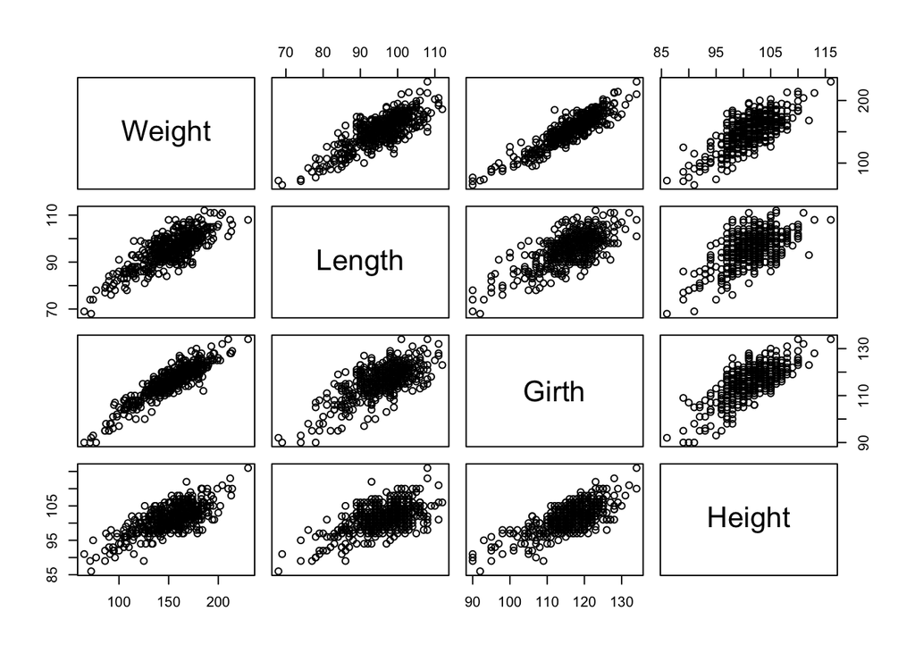

```r
# pairs(Weight~BCS + Age + Sex + Length + Girth + Height, data = donkeys)
pairs(Weight~Length + Girth + Height, data = train)
```

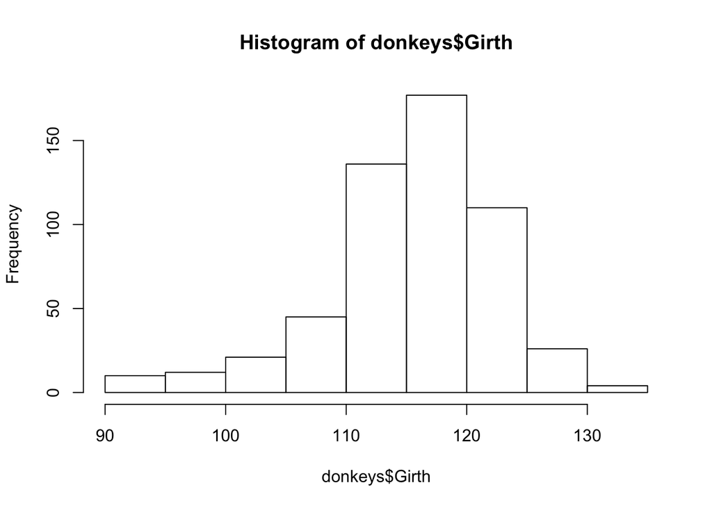

```r
# Distributions of Quantitative variables
hist(donkeys$Girth)
```

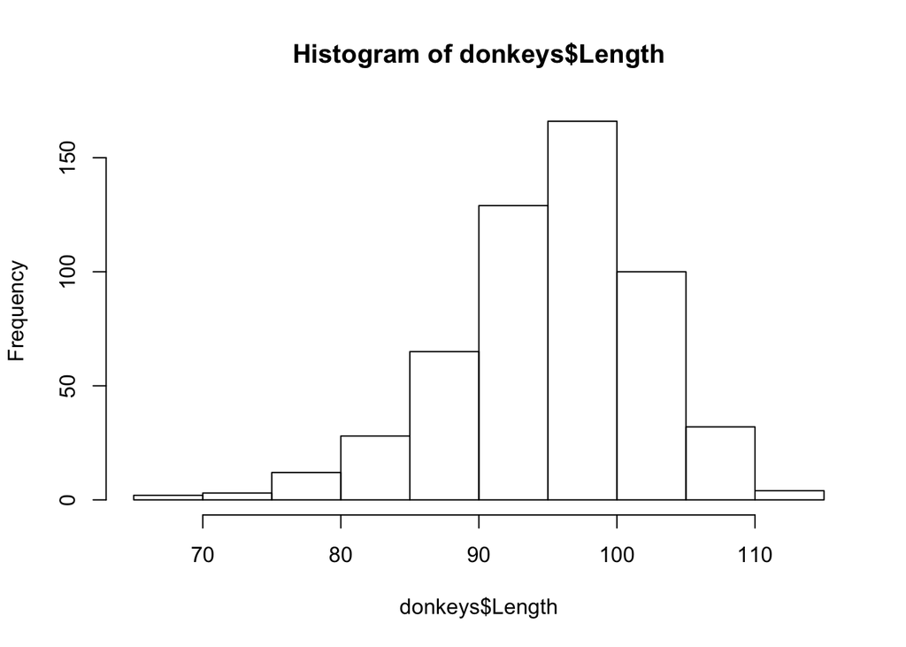

```r
hist(donkeys$Length)
```

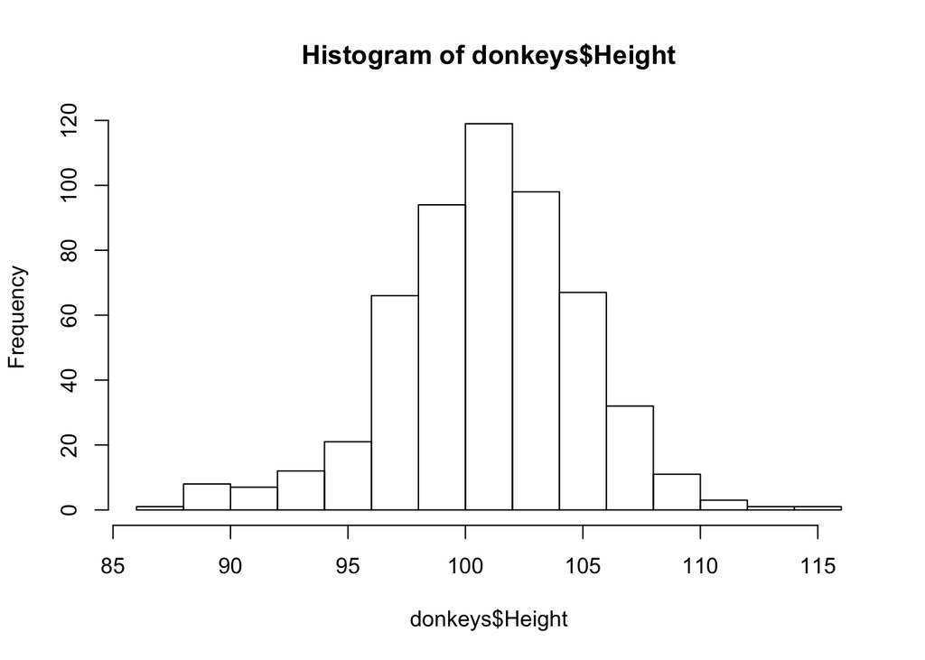

```r
hist(donkeys$Height)
```

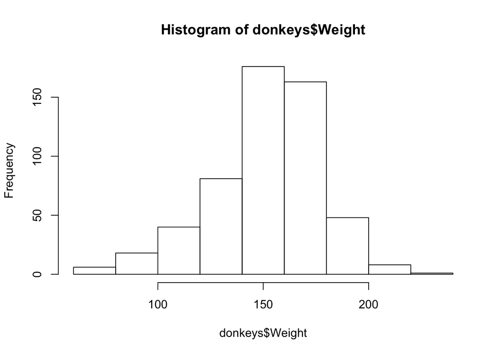

```r
hist(donkeys$Weight)
```

# Naive full model

```r
m1 = lm(Weight~ BCS + Age + Sex + Length + Girth + Height, data=train)
summary(m1)
```

```
##
## Call:
## lm(formula = Weight ~ BCS + Age + Sex + Length + Girth + Height,
##     data = train)
##
## Residuals:
##      Min       1Q   Median       3Q      Max
## -25.2041  -5.2252   0.3282   5.3344  20.1504
##
## Coefficients:
##               Estimate Std. Error t value Pr(>|t|)
## (Intercept) -241.42844   11.61721 -20.782  < 2e-16 ***
## BCS2           4.63727    4.00023   1.159  0.24702
## BCS2.5         5.82183    3.70543   1.571  0.11690
## BCS3          11.77358    3.70713   3.176  0.00160 **
## BCS3.5        19.31807    3.94083   4.902 1.36e-06 ***
## BCS4          26.61151    4.55664   5.840 1.05e-08 ***
## Age>20         6.94771    2.30665   3.012  0.00275 **
## Age10-15       7.92019    1.91817   4.129 4.40e-05 ***
## Age15-20      10.03945    2.39384   4.194 3.35e-05 ***
## Age2-5         3.41260    1.74298   1.958  0.05091 .
## Age5-10        6.01719    1.98971   3.024  0.00265 **
## Sexgelding    -0.50550    1.23389  -0.410  0.68225
## Sexstallion    0.35871    0.86357   0.415  0.67808
## Length         0.87930    0.08142  10.800  < 2e-16 ***
## Girth          1.74960    0.10899  16.053  < 2e-16 ***
## Height         0.88168    0.14675   6.008 4.09e-09 ***
## ---
## Signif. codes:  0 '***' 0.001 '**' 0.01 '*' 0.05 '.' 0.1 ' ' 1
##
## Residual standard error: 7.93 on 417 degrees of freedom
## Multiple R-squared:  0.9095, Adjusted R-squared:  0.9063
## F-statistic: 279.4 on 15 and 417 DF,  p-value: < 2.2e-16
```

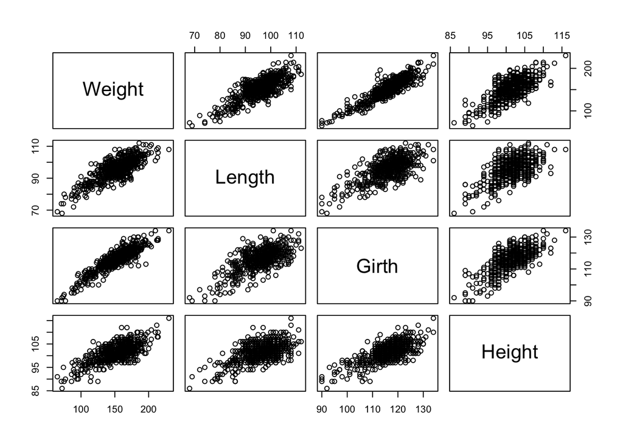

```r
# normal pairs
pairs(Weight ~ Length + Girth + Height, data = donkeys)
```

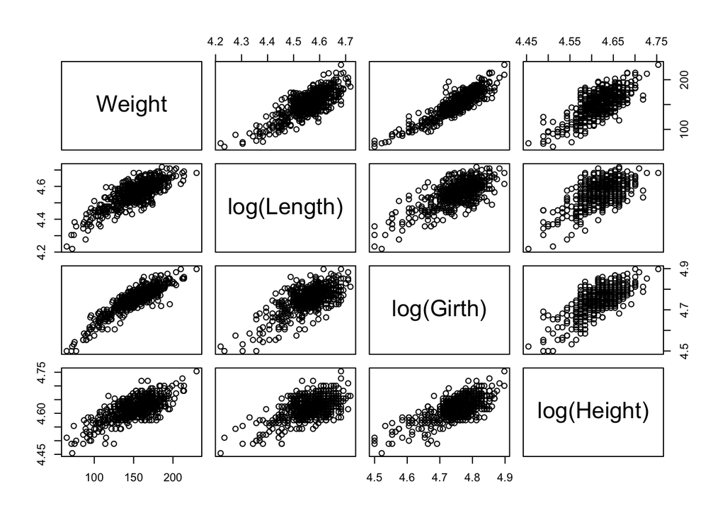

```r
# pairs logged
pairs(Weight ~ log(Length) + log(Girth) + log(Height), data = donkeys)
```

```r
predictions = predict.lm(m1, test, interval="confidence")
```

```r
residuals = predictions[,1] - test$Weight
MSE = mean(residuals^2)
MSE
```

```
## [1] 78.53406
```

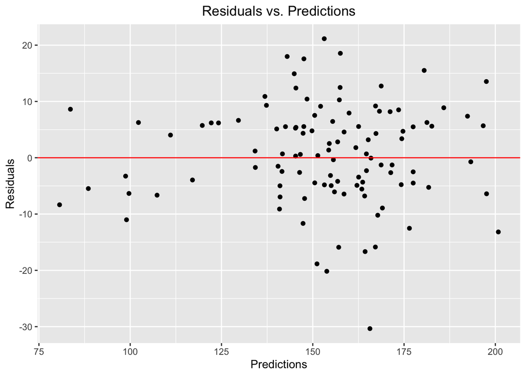

```r
test <- test %>% mutate(Residuals = residuals, Predictions=predictions[,1])
ggplot(data=test, aes(x=Predictions, y=Residuals)) + geom_point() +
  geom_hline(yintercept=0,color="red") +
  labs(title="Residuals vs. Predictions") +
  theme(plot.title=element_text(hjust=0.5))
```

```r
library(olsrr)
stepwise = ols_step_both_aic(m1)
stepwise
```

```
##
##
##                                   Stepwise Summary
## -----------------------------------------------------------------------------------
## Variable     Method       AIC          RSS         Sum Sq       R-Sq      Adj. R-Sq
## -----------------------------------------------------------------------------------
## Girth       addition    3290.304    49904.050    239875.978    0.82779      0.82739
## Length      addition    3151.906    36084.341    253695.687    0.87548      0.87490
## BCS         addition    3083.219    30088.220    259691.807    0.89617      0.89446
## Height      addition    3051.509    27834.600    261945.427    0.90395      0.90213
## Age         addition    3036.205    26254.593    263525.434    0.90940      0.90659
## -----------------------------------------------------------------------------------
```

```r
forward = ols_step_forward_aic(m1)
forward
```

```
##
##                            Selection Summary
## ------------------------------------------------------------------------
## Variable       AIC         Sum Sq         RSS        R-Sq      Adj. R-Sq
## ------------------------------------------------------------------------
## Girth        3290.304    239875.978    49904.050    0.82779      0.82739
## Length       3151.906    253695.687    36084.341    0.87548      0.87490
## BCS          3083.219    259691.807    30088.220    0.89617      0.89446
## Height       3051.509    261945.427    27834.600    0.90395      0.90213
## Age          3036.205    263525.434    26254.593    0.90940      0.90659
## ------------------------------------------------------------------------
```

```r
backward = ols_step_backward_aic(m1)
backward
```

```
##
##
##                        Backward Elimination Summary
## -------------------------------------------------------------------------
## Variable        AIC          RSS         Sum Sq       R-Sq      Adj. R-Sq
## -------------------------------------------------------------------------
## Full Model    3039.650    26221.008    263559.019    0.90951      0.90626
## Sex           3036.205    26254.593    263525.434    0.90940      0.90659
## -------------------------------------------------------------------------
```

# Getting rid of sex

```r
m2 = lm(Weight~ BCS + Age  + Length + Girth + Height, data=train)
summary(m2)
```

```
##
## Call:
## lm(formula = Weight ~ BCS + Age + Length + Girth + Height, data = train)
##
## Residuals:
##     Min      1Q  Median      3Q     Max
## -24.921  -5.328   0.398   5.310  20.078
##
## Coefficients:
##               Estimate Std. Error t value Pr(>|t|)
## (Intercept) -240.77270   11.51143 -20.916  < 2e-16 ***
## BCS2           4.73536    3.99047   1.187  0.23603
## BCS2.5         5.89082    3.69763   1.593  0.11188
## BCS3          11.83981    3.69917   3.201  0.00148 **
## BCS3.5        19.37644    3.93294   4.927 1.21e-06 ***
## BCS4          26.66577    4.53826   5.876 8.59e-09 ***
## Age>20         6.81767    2.27941   2.991  0.00294 **
## Age10-15       7.92686    1.90305   4.165 3.78e-05 ***
## Age15-20       9.96148    2.35670   4.227 2.91e-05 ***
## Age2-5         3.50684    1.73175   2.025  0.04350 *
## Age5-10        6.06240    1.98027   3.061  0.00234 **
## Length         0.87817    0.08025  10.943  < 2e-16 ***
## Girth          1.74216    0.10778  16.164  < 2e-16 ***
## Height         0.88474    0.14158   6.249 1.02e-09 ***
## ---
## Signif. codes:  0 '***' 0.001 '**' 0.01 '*' 0.05 '.' 0.1 ' ' 1
##
## Residual standard error: 7.916 on 419 degrees of freedom
## Multiple R-squared:  0.9094, Adjusted R-squared:  0.9066
## F-statistic: 323.5 on 13 and 419 DF,  p-value: < 2.2e-16
```

```r
predictions = predict.lm(m2, test, interval="confidence")
```

```r
residuals = predictions[,1] - test$Weight
MSE = mean(residuals^2)
MSE
```

```
## [1] 78.60046
```

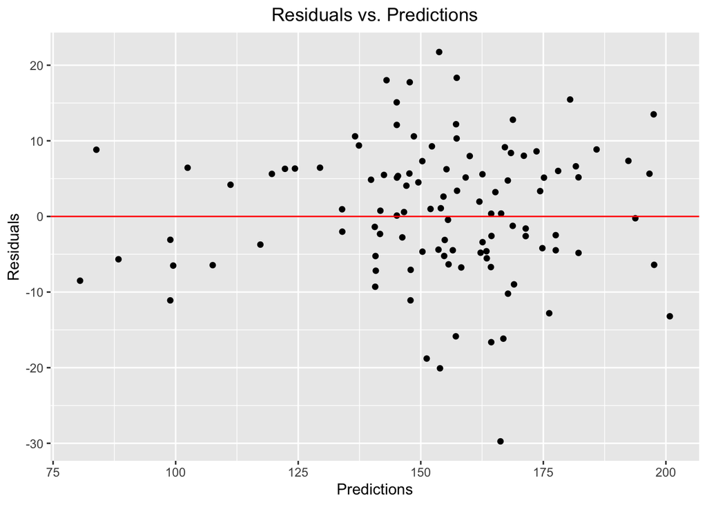

```r
test <- test %>% mutate(Residuals = residuals, Predictions=predictions[,1])
ggplot(data=test, aes(x=Predictions, y=Residuals)) + geom_point() +
  geom_hline(yintercept=0,color="red") +
  labs(title="Residuals vs. Predictions") +
  theme(plot.title=element_text(hjust=0.5))
```

```r
m3 = lm(Weight~ BCS + Age + log(Length) + log(Girth) + log(Height), data=train)
summary(m3)
```

```
##
## Call:
## lm(formula = Weight ~ BCS + Age + log(Length) + log(Girth) +
##     log(Height), data = train)
##
## Residuals:
##      Min       1Q   Median       3Q      Max
## -25.3518  -5.2623   0.3272   5.2763  19.8742
##
## Coefficients:
##              Estimate Std. Error t value Pr(>|t|)
## (Intercept) -1573.025     55.590 -28.297  < 2e-16 ***
## BCS2            4.739      4.055   1.169 0.243221
## BCS2.5          5.593      3.761   1.487 0.137744
## BCS3           11.786      3.762   3.133 0.001854 **
## BCS3.5         19.747      3.997   4.941 1.13e-06 ***
## BCS4           28.190      4.601   6.127 2.07e-09 ***
## Age>20          5.589      2.346   2.382 0.017664 *
## Age10-15        6.768      1.968   3.440 0.000641 ***
## Age15-20        8.958      2.421   3.700 0.000244 ***
## Age2-5          2.096      1.784   1.175 0.240846
## Age5-10         4.713      2.044   2.306 0.021603 *
## log(Length)    80.782      7.708  10.481  < 2e-16 ***
## log(Girth)    193.953     12.450  15.579  < 2e-16 ***
## log(Height)    90.815     14.576   6.231 1.13e-09 ***
## ---
## Signif. codes:  0 '***' 0.001 '**' 0.01 '*' 0.05 '.' 0.1 ' ' 1
##
## Residual standard error: 8.044 on 419 degrees of freedom
## Multiple R-squared:  0.9064, Adjusted R-squared:  0.9035
## F-statistic: 312.3 on 13 and 419 DF,  p-value: < 2.2e-16
```

```r
predictions = predict.lm(m3, test, interval="confidence")
```

```r
residuals = predictions[,1] - test$Weight
MSE = mean(residuals^2)
MSE
```

```
## [1] 81.07883
```

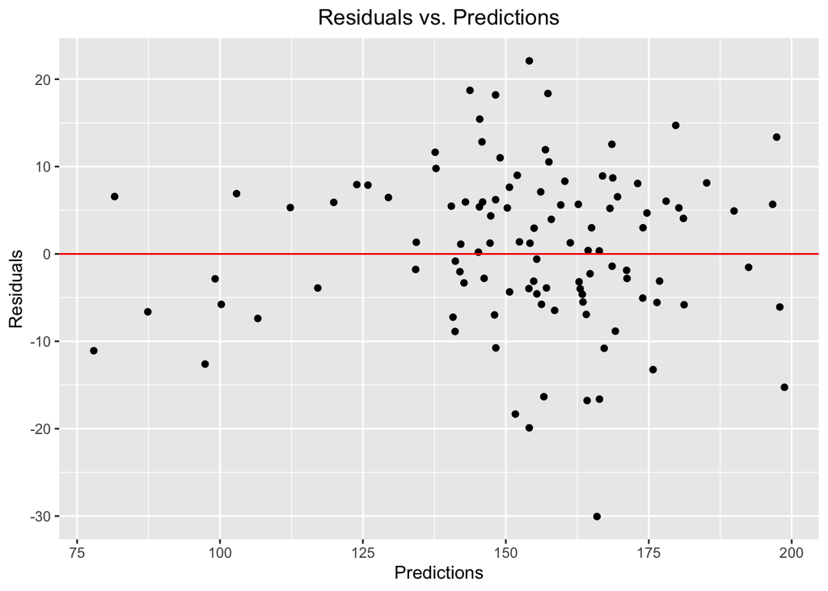

```r
test <- test %>% mutate(Residuals = residuals, Predictions=predictions[,1])
ggplot(data=test, aes(x=Predictions, y=Residuals)) + geom_point() +
  geom_hline(yintercept=0,color="red") +
  labs(title="Residuals vs. Predictions") +
  theme(plot.title=element_text(hjust=0.5))
```

# Reproducing Modeling

```r
train_reproducing = read.csv("train_reproducing.csv")
train_reproducing
```

[output not shown]

[output cut: 174 more lines]

```r
model <- lm(2*(sqrt(Weight)-1) ~ log(Length) + log(Girth), data=train_reproducing)
summary(model)
```

```
##
## Call:
## lm(formula = 2 * (sqrt(Weight) - 1) ~ log(Length) + log(Girth),
##     data = train_reproducing)
##
## Residuals:
##      Min       1Q   Median       3Q      Max
## -1.97980 -0.42350  0.07277  0.47901  1.70115
##
## Coefficients:
##              Estimate Std. Error t value Pr(>|t|)
## (Intercept) -103.5526     7.5650 -13.688  < 2e-16 ***
## log(Length)    7.0797     0.9577   7.393 4.82e-12 ***
## log(Girth)    19.7993     1.5386  12.869  < 2e-16 ***
## ---
## Signif. codes:  0 '***' 0.001 '**' 0.01 '*' 0.05 '.' 0.1 ' ' 1
##
## Residual standard error: 0.7051 on 185 degrees of freedom
## Multiple R-squared:  0.6065, Adjusted R-squared:  0.6022
## F-statistic: 142.6 on 2 and 185 DF,  p-value: < 2.2e-16
```